Drawing for the owner · 23 Nov 2026 · round 3

# Reveals, at the veil’s pace

Every reveal now follows the rules of your veil: how it answers the finger, how slowly it starts, how softly it lands. Marble and burning paper are retired. Petals and Fireworks take their places, as you picked. The gift box was held back; it is redrawn here for your eye, last on the shelf. These are the nine.

[interactive chart not shown]

Loading the live version…

## Every reveal has its own options

You asked that each one can be customised from a set of styles. Pick a reveal above; its options are the dropdowns under the phone. A change shows at once. These are the first sets: say what to add or drop.

- **Veil**Logo pattern: small (now the default), tiny, large, none. Bottom edge: plain, lace scallops, embroidered vine, pearl beads.
- **Beach curtains**Fabric: sheer voile, linen, lace, striped gauze. Colour: ivory, white, blush, sand, sage.
- **Fabric**Fabric: plain satin, damask jacquard, raw mulberry silk, chiffon, velvet, linen, organza, tulle, lace. Colour: champagne, ivory, blush, mulberry, emerald, midnight.
- **Scratch**Foil colour: gold, silver, rose gold, emerald, midnight.
- **Smoke**Smoke colour: white, blush, gold, twilight.
- **Petals**Petal: rose, sampaguita, cherry blossom. Two colours of your choice from eight; the petals are those two and the shades between.
- **Fireworks**Colours: gold, rose gold, silver white, or gold with pink and blue. Burst: round, willow, rings, hearts.
- **Envelope · classic**Flap shape: scalloped, deep V, pointed Euro, rounded, square, double scallop, deckle edge. Flap design: damask, lilies, plain with a gold edge. Paper colour: ivory, blush, sage, dusty blue, burgundy, navy. Seal: gold, rose gold, silver, burgundy wax, sage wax. The foil edge follows the seal.
- **Envelope · gatefold**Closed with: a wax seal, or a ribbon and bow (never both). Panel design: sculpted lilies, damask, plain with a border, art deco, botanical line, lace, geometric, monogram field, pressed florals. The same six paper colours and five seals. Ribbon: blush, ivory, sage, dusty blue, burgundy, gold.
- **Gift box (still held)**Wrap colour: emerald, ivory, blush, navy, burgundy, kraft. Wrap print: your monogram, gold dots, gold stripes, plain. Ribbon: six colours. Bow: classic or double. Floor: evening linen, warm wood, marble, ivory linen, stone, sand, cotton clouds, Egyptian cotton, ivory clouds. Around the box: flowers, rose petals, pearls, diamonds, confetti, balloons, gold stars, or nothing. Lining: gold lamé, ivory satin, blush silk, navy velvet, sage linen, plain card.
- **Cathedral doors**Doors: carved wood, midnight blue, gold leaf. Flowers: white, blush, peach, lilac. New in the hall for everyone: pillar candles along the aisle, mirrored in the floor, and petals drifting down.

## The veil’s motion rules

Read from the shipped veil (the cloth solver, the reveal loop and the owner-locked numbers). Every reveal on this page uses these, from one shared rules file. None has timing of its own.

1. 1

   **A tap opens it by itself, very slowly.**12 seconds here; your live veil takes 5. Try 9, 12 or 16 with the buttons under the phone. It starts at once and keeps an even, unhurried pace, as in your videos.
2. 2

   **Nothing snaps.**Each frame the motion closes 5% of the distance left. So it starts slowly and lands softly, never at a stop.
3. 3

   **It follows the finger.**Touch the cloth and the threads under your finger gather to it and come toward you. Move, and they move with you.
4. 4

   **Let go, and it falls back on its own.**No animation is played. The cloth swings back by its weight, overshoots a little, and settles.
5. 5

   **A quick swipe the way it opens throws it open.**Over 40 px in under half a second. The other way closes it again.
6. 6

   **Heavy, well damped.**Each frame keeps about 98% of its speed, so a swing dies in two or three passes, not ten.
7. 7

   **Cloth folds, it does not stretch.**It gives easily when pushed together, so folds form, and stops firmly at 1.2% longer than its length.
8. 8

   **It gets lighter as it opens.**While lifting, the veil loses most of its weight, so it floats up instead of being yanked.
9. 9

   **A breath of wind, more at the hem.**The top is still. The sway grows toward the free edge.
10. 10

    **Light and shadow move with it.**Cloth turns whiter and more solid where it folds away from you. Solid things throw a soft moving shadow on the cover.
11. 11

    **The view moves in, slowly.**While it opens, the camera travels toward the reveal and on past it, so you arrive at the cover.
12. 12

    **The cover shows only at the very end.**“Open” is called at 98.5% of the motion. Then the reveal fades and the cover is plain.

## The nine, with the envelope in two styles

Four frames each, taken from the live version: closed, then about 4.5, 7 and 10 seconds after the tap, at the 12-second speed. Cloth ones also show held, let go, settled.

1

### Veil

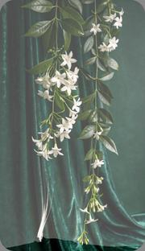

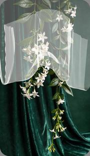

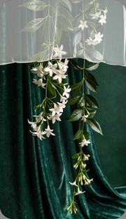

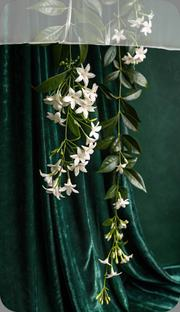

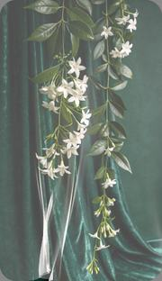

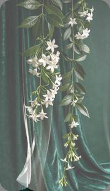

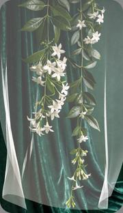

heldlet gosettled

The shipped veil’s cloth, solver and pinch. It unveils from where you tap: the cloth under your finger is taken up first and the rest follows. Then it stays, hanging as a soft fold along the top, as on your Event Hub.

**You do**

Tap, swipe up, or pinch the cloth and pull.

**Status**

Live on cale-ice. Changed here: lifts from the tapped point, and slower.

2

### Beach curtains

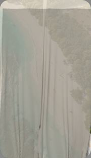

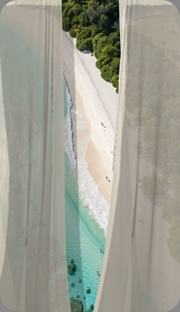

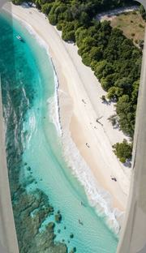

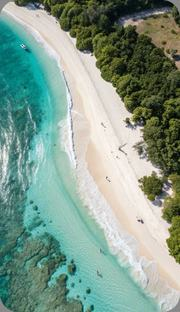

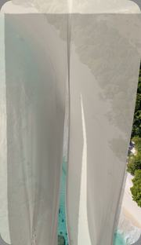

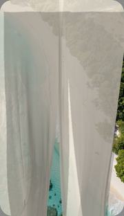

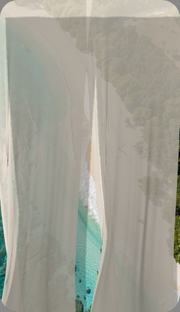

heldlet gosettled

The veil’s cloth in a thicker thread, hung in two halves on a rod. The inner ring leads and the others stack behind it; the cloth swings in after its rings and settles.

**You do**

Tap, swipe up, or take hold of a curtain.

**Status**

New, on the veil’s engine.

3

### Envelope · classic

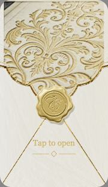

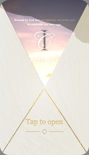

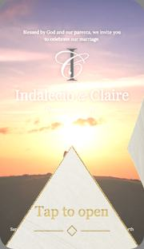

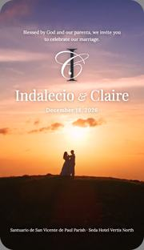

Made to read as a photograph: paper that takes the light across its embossing, a gold foil edge and a gold wax seal that mirror a room, soft shadows from one flap onto the next. The front flap bends as paper does while it unfolds upward, and the seal stays on its point and rises with it. The cover shows as soon as it opens, with a soft glow that passes.

**You do**

Tap the seal.

**Status**

Rebuilt for realism, from your picture. Style 1 of 2.

4

### Envelope · gatefold

[figure not shown]

[figure not shown]

[figure not shown]

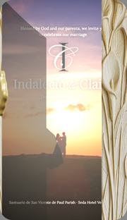

Two tall panels of sculpted lilies, closed by a gold wax seal with your monogram on the seam. The seal is never cut in two: on one tap it lifts away whole with the left panel. The panels part slowly, like doors, and light comes from inside. You can choose a satin ribbon and bow in place of the seal: the bow comes undone, the ribbon is drawn off, and the panels part. It is one or the other, never both.

**You do**

Tap the seal.

**Status**

Changed 23 Nov: a wax seal OR a ribbon, never both. The seal stays whole. Six more panel designs.

5

### Fabric

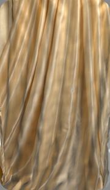

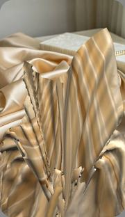

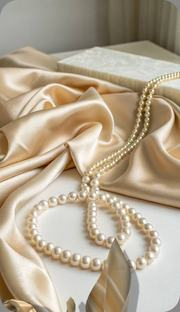

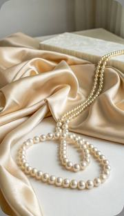

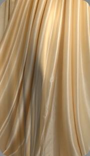

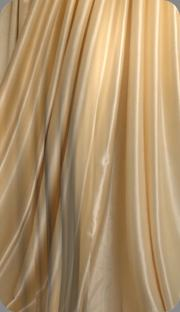

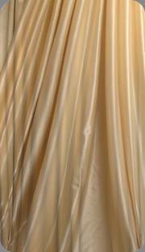

heldlet gosettled

One length of satin with a twist in it, lying on the cover like a cloth on a table. A pinch of it is taken where you tap and drawn down and off the screen. It does not fall: the rest follows the hand, and its corners draw together as it goes.

**You do**

Tap, or take a fold and pull.

**Status**

Rebuilt: dragged off, not dropped.

6